# Project Foundations for Data Science: FoodHub Data Analysis

**Marks: 60**

### Context

The number of restaurants in New York is increasing day by day. Lots of students and busy professionals rely on those restaurants due to their hectic lifestyles. Online food delivery service is a great option for them. It provides them with good food from their favorite restaurants. A food aggregator company FoodHub offers access to multiple restaurants through a single smartphone app.

The app allows the restaurants to receive a direct online order from a customer. The app assigns a delivery person from the company to pick up the order after it is confirmed by the restaurant. The delivery person then uses the map to reach the restaurant and waits for the food package. Once the food package is handed over to the delivery person, he/she confirms the pick-up in the app and travels to the customer's location to deliver the food. The delivery person confirms the drop-off in the app after delivering the food package to the customer. The customer can rate the order in the app. The food aggregator earns money by collecting a fixed margin of the delivery order from the restaurants.

### Objective

The food aggregator company has stored the data of the different orders made by the registered customers in their online portal. They want to analyze the data to get a fair idea about the demand of different restaurants which will help them in enhancing their customer experience. Suppose you are hired as a Data Scientist in this company and the Data Science team has shared some of the key questions that need to be answered. Perform the data analysis to find answers to these questions that will help the company to improve the business.

### Data Description

The data contains the different data related to a food order. The detailed data dictionary is given below.

### Data Dictionary

- order_id: Unique ID of the order
- customer_id: ID of the customer who ordered the food
- restaurant_name: Name of the restaurant
- cuisine_type: Cuisine ordered by the customer
- cost: Cost of the order
- day_of_the_week: Indicates whether the order is placed on a weekday or weekend (The weekday is from Monday to Friday and the weekend is Saturday and Sunday)
- rating: Rating given by the customer out of 5
- food_preparation_time: Time (in minutes) taken by the restaurant to prepare the food. This is calculated by taking the difference between the timestamps of the restaurant's order confirmation and the delivery person's pick-up confirmation.
- delivery_time: Time (in minutes) taken by the delivery person to deliver the food package. This is calculated by taking the difference between the timestamps of the delivery person's pick-up confirmation and drop-off information

### Let us start by importing the required libraries

```python
!pip install nbconvert
```

```python
# Library to suppress warnings
import warnings
warnings.filterwarnings('ignore')
```

```python
from google.colab import drive
drive.mount('/content/drive')
```

```python
import os
os.listdir(os.getcwd()+'/drive/MyDrive/adsp_laiedm/week_1_py_for_ds/project_assessment')
file_dir = '/content/drive/MyDrive/adsp_laiedm/week_1_py_for_ds/project_assessment'
! jupyter nbconvert --to html  '/content/drive/MyDrive/adsp_laiedm/week_1_py_for_ds/project_assessment/FDS_Project_LearnerNotebook_FullCode.ipynb'
```

```
[NbConvertApp] Converting notebook /content/drive/MyDrive/adsp_laiedm/week_1_py_for_ds/project_assessment/FDS_Project_LearnerNotebook_FullCode.ipynb to html
[NbConvertApp] WARNING | Alternative text is missing on 17 image(s).
[NbConvertApp] Writing 1999193 bytes to /content/drive/MyDrive/adsp_laiedm/week_1_py_for_ds/project_assessment/FDS_Project_LearnerNotebook_FullCode.html
```

```python
# import libraries for data manipulation
import numpy as np
import pandas as pd

# import libraries for data visualization
import matplotlib.pyplot as plt
import seaborn as sns
```

### Understanding the structure of the data

```python
# read the data
df = pd.read_csv(file_dir+'/foodhub_order.csv')
# returns the first 5 rows
df.head()
```

|  | order_id | customer_id | restaurant_name | cuisine_type | cost_of_the_order | day_of_the_week | rating | food_preparation_time | delivery_time |
| --- | --- | --- | --- | --- | --- | --- | --- | --- | --- |
| 0 | 1477147 | 337525 | Hangawi | Korean | 30.75 | Weekend | Not given | 25 | 20 |
| 1 | 1477685 | 358141 | Blue Ribbon Sushi Izakaya | Japanese | 12.08 | Weekend | Not given | 25 | 23 |
| 2 | 1477070 | 66393 | Cafe Habana | Mexican | 12.23 | Weekday | 5 | 23 | 28 |
| 3 | 1477334 | 106968 | Blue Ribbon Fried Chicken | American | 29.20 | Weekend | 3 | 25 | 15 |
| 4 | 1478249 | 76942 | Dirty Bird to Go | American | 11.59 | Weekday | 4 | 25 | 24 |

#### Observations:

The DataFrame has 9 columns as mentioned in the Data Dictionary. Data in each row corresponds to the order placed by a customer.

### **Question 1:** How many rows and columns are present in the data? [0.5 mark]

```python
# output shown has first value as the number of rows and second its number of columns
rows, cols = (df.shape)
print(rows, cols)
```

```
1898 9
```

#### Observations:

### **Question 2:** What are the datatypes of the different columns in the dataset? (The info() function can be used) [0.5 mark]

```python
# Use info() to print a concise summary of the DataFrame
df.info()
```

```
<class 'pandas.core.frame.DataFrame'>
RangeIndex: 1898 entries, 0 to 1897
Data columns (total 9 columns):
 #   Column                 Non-Null Count  Dtype
---  ------                 --------------  -----
 0   order_id               1898 non-null   int64
 1   customer_id            1898 non-null   int64
 2   restaurant_name        1898 non-null   object
 3   cuisine_type           1898 non-null   object
 4   cost_of_the_order      1898 non-null   float64
 5   day_of_the_week        1898 non-null   object
 6   rating                 1898 non-null   object
 7   food_preparation_time  1898 non-null   int64
 8   delivery_time          1898 non-null   int64
dtypes: float64(1), int64(4), object(4)
memory usage: 133.6+ KB
```

#### Observations:

### **Question 3:** Are there any missing values in the data? If yes, treat them using an appropriate method. [1 mark]

```python
# Write your code here
df.isna().sum()
```

|  | 0 |
| --- | --- |
| order_id | 0 |
| customer_id | 0 |
| restaurant_name | 0 |
| cuisine_type | 0 |
| cost_of_the_order | 0 |
| day_of_the_week | 0 |
| rating | 0 |
| food_preparation_time | 0 |
| delivery_time | 0 |

**dtype:** int64

#### Observations:

### **Question 4:** Check the statistical summary of the data. What is the minimum, average, and maximum time it takes for food to be prepared once an order is placed? [2 marks]

```python
#Descriptive statics of food data set for #cost_of_the_order , #food_preparation_time	and #delivery_time
df.describe(include='number').T
```

|  | count | mean | std | min | 25% | 50% | 75% | max |
| --- | --- | --- | --- | --- | --- | --- | --- | --- |
| order_id | 1898.0 | 1.477496e+06 | 548.049724 | 1476547.00 | 1477021.25 | 1477495.50 | 1.477970e+06 | 1478444.00 |
| customer_id | 1898.0 | 1.711685e+05 | 113698.139743 | 1311.00 | 77787.75 | 128600.00 | 2.705250e+05 | 405334.00 |
| cost_of_the_order | 1898.0 | 1.649885e+01 | 7.483812 | 4.47 | 12.08 | 14.14 | 2.229750e+01 | 35.41 |
| food_preparation_time | 1898.0 | 2.737197e+01 | 4.632481 | 20.00 | 23.00 | 27.00 | 3.100000e+01 | 35.00 |
| delivery_time | 1898.0 | 2.416175e+01 | 4.972637 | 15.00 | 20.00 | 25.00 | 2.800000e+01 | 33.00 |

```python
# Write your code here
#df.describe(include="all").T.loc['rating':,['min','mean','max']]

df.describe(include="all").T.loc['food_preparation_time',['min','mean','max']]


#It takes about average of 27.37197 ~27.4 mins , minimum of 20.0 mins and a maximum of 35.0 mins
```

|  | food_preparation_time |
| --- | --- |
| min | 20.0 |
| mean | 27.37197 |
| max | 35.0 |

**dtype:** object

```python
df.describe(include="all").T.loc['delivery_time',['min','mean','max']]
```

|  | delivery_time |
| --- | --- |
| min | 15.0 |
| mean | 24.161749 |
| max | 33.0 |

**dtype:** object

```python
##Descriptive statics of foodhub data set categorical columns / categories

#There are about restaurants (restaurant_name) - 178
#cuisines (cuisine_type) - 14
#Customer ratings on there order (rating) -  3, 4, 5 and 'Not Given'. 'Not Given' - being the highest.

df.describe(exclude='number').T
```

|  | count | unique | top | freq |
| --- | --- | --- | --- | --- |
| restaurant_name | 1898 | 178 | Shake Shack | 219 |
| cuisine_type | 1898 | 14 | American | 584 |
| day_of_the_week | 1898 | 2 | Weekend | 1351 |
| rating | 1898 | 4 | Not given | 736 |

```python
#rating and its counts
df.rating.value_counts()
```

| rating | count |
| --- | --- |
| Not given | 736 |
| 5 | 588 |
| 4 | 386 |
| 3 | 188 |

**dtype:** int64

#### Observations:

### **Question 5:** How many orders are not rated? [1 mark]

```python
# Write the code here
orders_not_rated = df.rating.value_counts()['Not given']
print(orders_not_rated)
```

```
736
```

#### Observations:

### Exploratory Data Analysis (EDA)

### **Question 6:** Explore all the variables and provide observations on their distributions. (Generally, histograms, boxplots, countplots, etc. are used for univariate exploration.) [9 marks]

```python
def histogram_boxplot(feature, figsize=(15, 10), bins="auto"):
    """ Boxplot and histogram combined
    feature: 1-d feature array
    figsize: size of fig (default (15, 10))
    bins: number of bins (default "auto")
    """
    f, (ax_box, ax_hist) = plt.subplots(
        nrows=2,  # Number of rows of the subplot grid
        sharex=True,  # The X-axis will be shared among all the subplots
        gridspec_kw={"height_ratios": (.25, .75)},
        figsize=figsize
    )

    # Creating the subplots
    # Boxplot will be created and the mean value of the column will be indicated using some symbol
    sns.boxplot(x=feature, ax=ax_box, showmeans=True, color='red')

    # For histogram
    sns.histplot(x=feature, kde=True, ax=ax_hist, bins=bins)
    ax_hist.axvline(np.mean(feature), color='w', linestyle='--')      # Add mean to the histogram
    ax_hist.axvline(np.median(feature), color='black', linestyle='-') # Add median to the histogram

    plt.show()
```

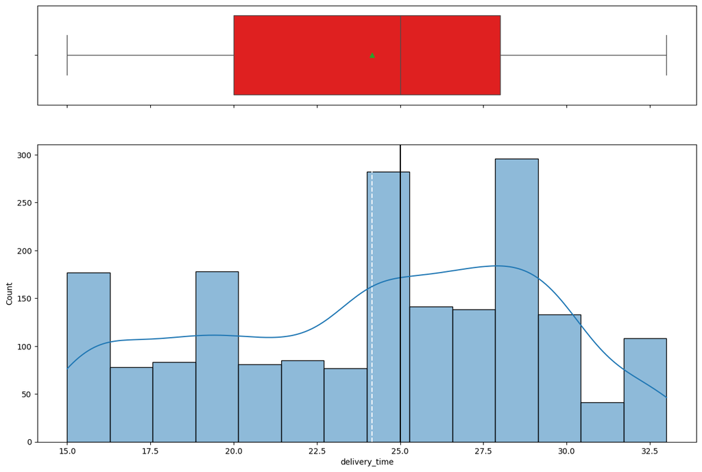

```python
histogram_boxplot(df.delivery_time)
```

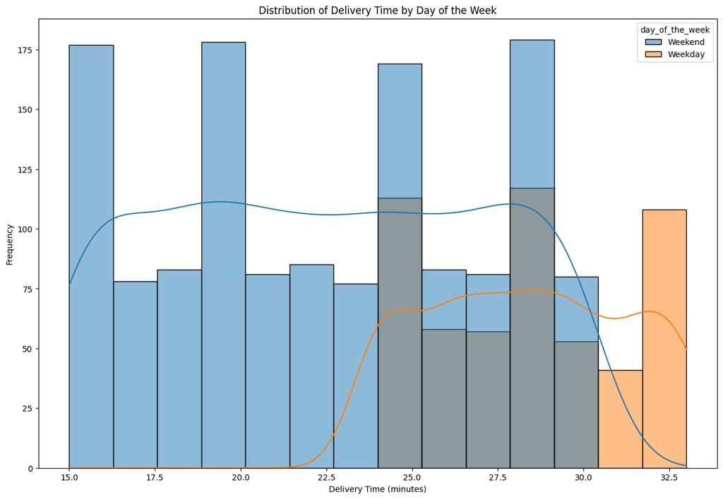

```python
#Individual histogram plot
plt.figure(figsize=(15, 10))
sns.histplot(data=df, x='delivery_time', kde=True, hue='day_of_the_week')
plt.title('Distribution of Delivery Time by Day of the Week')
plt.xlabel('Delivery Time (minutes)')
plt.ylabel('Frequency')
plt.show()

#This shows it has multimodality
```

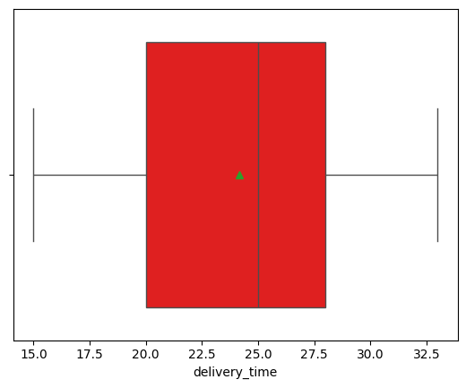

```python
# Boxplot will be created and the mean value of the column will be indicated using some symbol
sns.boxplot(data=df, x='delivery_time', showmeans=True, color='red')
plt.show()
```

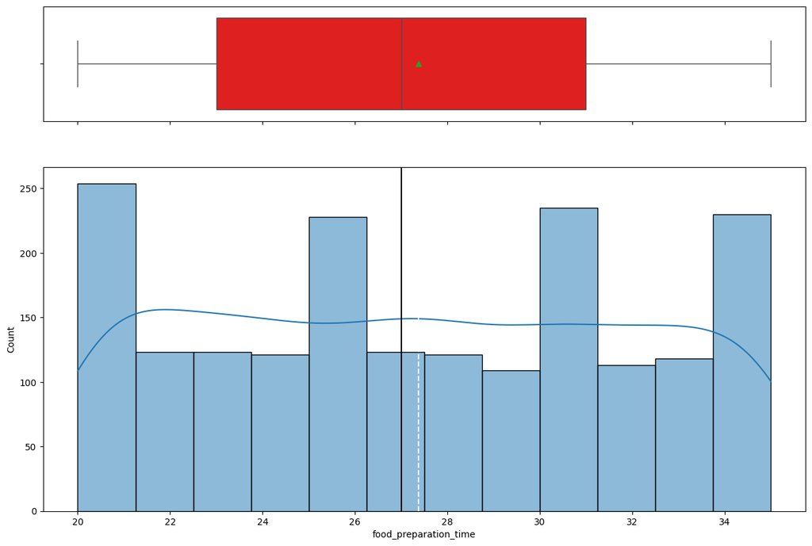

```python
#Univariate analysis for the food_preparation_time
histogram_boxplot(df.food_preparation_time)
```